# Quantifying the therapeutic alliance: A methodological framework for conducting observational moment-by-moment research

This is a step-by-step guide to illustrate the contents of the paper *“Quantifying the therapeutic alliance: A methodological framework for conducting observational moment-by-moment research”*.

# Setup

## Custom functions

The analyses in this tutorial rely on four custom R functions (`permanent_group`, `sequence_descriptives`, `sequence_heatmap`, and `sequence_trajectory`), all defined in `dyadObs_functions.r`. The chunk below downloads this file to your R working directory and loads it. To find or edit the file afterwards, run `getwd()` in the R console — it will be saved there as `dyadObs_functions.r`.

```r
#download.file(
#  "https://raw.githubusercontent.com/dfernandezregueras/dyadObs/main/dyadObs_functions.r",
#  destfile = "dyadObs_functions.r"
#)
source("dyadObs_functions.r")
```

## Data files

This tutorial requires four data files. Download each one using the links below and save all of them to the folder shown by `getwd()` in R.

- data_1.xlsx
- data_2.xlsx
- [dyad 31.xlsx](https://github.com/dfernandezregueras/dyadObs/raw/main/dyad%2031.xlsx)
- [dyad 32.xlsx](https://github.com/dfernandezregueras/dyadObs/raw/main/dyad%2032.xlsx)

# 1. Preprocessing (observational data)

## 1.1 Load the observational data and merge the different files

Sometimes, data from different observations are stored in separate files. To prepare the data, we will merge them into a single file. The Observer XT provides `.xlsx` data files that contain several variables. For the data analysis, only a few of them are relevant:

- *Behavior*: Contains the names of the coded events in a longitudinal format.
- *Observation*: Contains the name assigned to each observation session. When coding, researchers must ensure that each session has a unique name. A common practice is to include an ID for the case and the session number (e.g., `case1_session1`). This variable represents repeated measures in a long format, as it includes all coded events within a session.
- *Subject*: Identifies the individual who emits the behavior (e.g., “Therapist” or “Client”).

The researcher may choose to retain the remaining variables. However, for simplicity, we will remove them since they are not needed for our analyses. If the researcher chooses to retain the additional variables and the data frames contain different variables (as in our case), the merge function should be used.

```r
library(readxl)

# Load the data files

data_1 <- read_excel("data_1.xlsx")[, c("Observation", "Subject", "Behavior")]
data_2 <- read_excel("data_2.xlsx")[, c("Observation", "Subject", "Behavior")]
data_3 <- read_excel("dyad 31.xlsx")[, c("Observation", "Subject", "Behavior")]
data_4 <- read_excel("dyad 32.xlsx")[, c("Observation", "Subject", "Behavior")]



# Merge the data (only three variables)

data <- rbind(data_1, data_2, data_3, data_4)


library(writexl)
write_xlsx(data, "Previous data.xlsx")

# Maintain the remaining variables

data <- Reduce(function(x, y) merge(x, y, by = c("Observation", "Subject", "Behavior"), all = T),
                      list(data_1, data_2, data_3, data_4))
```

## 1.2 Assign the sessions to the remaining variables: Phase of therapy, ID, Group

```r
library(readxl)

data <- read_excel("Previous data.xlsx")



# ASSIGN ID & Treatment phase

# Visualize the list of Observation sessions

unique_sessions <- unique(data$Observation)

unique_sessions <- as.data.frame(unique_sessions)


# Assign ID and Treatment phases based on the list of Observation sessions

session_lookup <- data.frame(
  Observation = unique(data$Observation),
  ID = rep(1:32, times = c(5, 5, 5, 5, 5, 5, 3, 5, 5, 5, 4, 5, 5, 5, 5, 5, 5, 5, 3, 5, 5, 5, 5, 5, 4, 5, 5, 5, 5, 5, 5, 5)),
  Treatment_Phase = c("Middle of intervention", "End of intervention", "Assessment", "Treatment planning", "Beginning of intervention",
                      "End of intervention","Assessment","Treatment planning","Beginning of intervention","Middle of intervention",
                      "Middle of intervention","End of intervention","Assessment","Treatment planning","Beginning of intervention",
                      "Beginning of intervention","Middle of intervention", "Assessment", "End of intervention", "Treatment planning",
                      "Middle of intervention","End of intervention","Assessment","Treatment planning","Beginning of intervention",
                      "Beginning of intervention","Middle of intervention","End of intervention","Assessment","Treatment planning",
                      "Assessment","Treatment planning","Beginning of intervention",
                      "Middle of intervention","End of intervention","Assessment","Treatment planning","Beginning of intervention",
                      "Middle of intervention","End of intervention","Assessment","Treatment planning","Beginning of intervention",
                      "Middle of intervention","End of intervention","Assessment","Treatment planning","Beginning of intervention",
                      "Assessment","Treatment planning","Beginning of intervention", "End of intervention",
                      "Middle of intervention","End of intervention","Assessment","Treatment planning","Beginning of intervention",
                      "Beginning of intervention","Middle of intervention","End of intervention","Assessment","Treatment planning",
                      "Middle of intervention","Assessment", "End of intervention", "Treatment planning","Beginning of intervention",
                      "Beginning of intervention","Middle of intervention","End of intervention","Assessment","Treatment planning",
                      "Middle of intervention","End of intervention","Assessment","Treatment planning","Beginning of intervention",
                      "Middle of intervention","End of intervention","Assessment","Beginning of intervention","Treatment planning",
                      "Beginning of intervention","Middle of intervention","End of intervention","Assessment","Treatment planning",
                      "Assessment","Treatment planning","Beginning of intervention",
                      "End of intervention","Assessment","Treatment planning","Beginning of intervention","Middle of intervention",
                      "Beginning of intervention","Middle of intervention","Assessment","End of intervention","Treatment planning",
                      "Beginning of intervention","Middle of intervention","Assessment","End of intervention","Treatment planning",
                      "Middle of intervention","End of intervention","Assessment","Treatment planning","Beginning of intervention",
                      "Middle of intervention","End of intervention","Assessment","Treatment planning","Beginning of intervention",
                      "Assessment","Treatment planning","Beginning of intervention","End of intervention",
                      "Middle of intervention","End of intervention","Assessment","Treatment planning","Beginning of intervention",
                      "End of intervention","Assessment","Treatment planning","Beginning of intervention","Middle of intervention",
                      "Beginning of intervention","Middle of intervention","End of intervention","Assessment","Treatment planning",
                      "Middle of intervention","End of intervention","Assessment","Treatment planning","Beginning of intervention",
                      "End of intervention","Assessment","Treatment planning","Beginning of intervention","Middle of intervention",
                      "Middle of intervention","End of intervention","Assessment","Treatment planning","Beginning of intervention",
                      "Middle of intervention","End of intervention","Assessment","Treatment planning","Beginning of intervention"
                      )
)


# Merge the assigned IDs and Treatment phases with the rest of data

library(dplyr)

data_merged <- left_join(data, session_lookup, by = "Observation")


# Check phases' names for potential typos

#unique(data_merged$Treatment_Phase)


##################################################################################

# ASSIGN GROUPS

# Visualize the list of IDs

unique_ID <- unique(data_merged$ID)

unique_ID <- as.data.frame(unique_ID)

# Assign Groups based on the list of IDs

ID_lookup <- data.frame(
  ID = unique(data_merged$ID),
  Group = c("Poor", "Poor", "Good", "Poor", "Poor", "Good", "Poor", "Good", "Good", "Poor", "Good", "Good", "Poor", "Good", "Good", "Poor", "Poor", "Good", "Poor", "Good", "Average", "Average", "Average", "Average", "Average", "Average", "Average", "Average", "Average", "Average", "Average", "Average")
)


# Merge the assigned Grups with the rest of data

data_complete <- left_join(data_merged, ID_lookup, by = "ID")

# Check Groups' names for potential typos

#unique(data_complete$Group)

head(data_complete)
```

| Observation | Subject | Behavior | ID | Treatment_Phase | Group |
| --- | --- | --- | --- | --- | --- |
| Dyad1_Session 10_Middle | Client | Providing information C | 1 | Middle of intervention | Poor |
| Dyad1_Session 10_Middle | Therapist | Total agreement T | 1 | Middle of intervention | Poor |
| Dyad1_Session 10_Middle | Client | Total agreement C | 1 | Middle of intervention | Poor |
| Dyad1_Session 10_Middle | Client | Providing information C | 1 | Middle of intervention | Poor |
| Dyad1_Session 10_Middle | Therapist | Total agreement T | 1 | Middle of intervention | Poor |
| Dyad1_Session 10_Middle | Therapist | Self-disclosure personal life T | 1 | Middle of intervention | Poor |

```r
library(writexl)
write_xlsx(data_complete, "Preprocessed data - phase names.xlsx")
```

## 1.3 Permanent grouping of behaviors

Some behaviors, either for theoretical reasons or due to their low frequency, need to be grouped. In future sections, we will present a more flexible approach for grouping behaviors for specific analyses without the need to permanently modify the dataset. However, some researchers may prefer to group behaviors permanently beforehand if they are certain that these behaviors should remain unified under the same label. In such cases, researchers may find the `permanent_group` function useful.

- `permanent_group` allows researchers to group behaviors under a single label before conducting analyses. Its simple usage requires researchers to input the names of the behaviors to be grouped, separated by a `+` symbol, as well as the name of the variable that store the behaviors and the name of the new grouped behavior created.

```r
library(readxl)
data <- read_excel("Preprocessed data - phase names.xlsx")
```

As an example, the client behaviors `Partial agreement` and `Disagreement`, which are theoretically related, will be unified into the new behavior `Group_1`.

```r
data <- permanent_group(data, "Behavior", "Partial agreement C + Disagreement C", "Group_1")
```

After preprocessing the data and obtaining the final dataset, it is always good practice to store it safely to avoid losing information and repeating the entire process.

```r
library(writexl)
write_xlsx(data, "Preprocessed data.xlsx")
```

# 2. Descriptive statistics (observational data)

Descriptive data will be useful for future decisions regarding the analyses. To provide a comprehensive description of the data, the function `sequence_descriptives` is able to provide descriptive statistics for both individual behaviors and sequences of an indefinite number of behaviors. The contents of this section will, therefore, apply to both individual behaviors and sequences.

## 2.1 Individual behaviors and sequences: descriptive statistics, normality tests and density distribution plots

### Key Features

1. **Flexible Behavior Grouping**:
   - Researchers can group behaviors using the `+` symbol (e.g., `"BehaviorA + BehaviorB"`) to treat them as the same during analysis.
   - This grouping is applied dynamically and does not modify the original dataset.
2. **Descriptive Statistics**:
   - Computes the following statistics for each treatment phase:
     - **Sample size**: Number of observation sessions per phase.
     - **Mean**: Mean relative frequency of behaviors/sequences.
     - **Median**: Median relative frequency of behaviors/sequences.
     - **Standard deviation**: Variability of relative frequencies.
     - **Percentile 5**: 5th percentile of relative frequencies.
     - **Percentile 95**: 95th percentile of relative frequencies.
     - **Skewness**: Measure of distribution asymmetry.
     - **Standard error of skewness**: Error associated with skewness.
     - **Kurtosis**: Measure of distribution tailedness.
   - Includes the **Shapiro-Wilk test** for normality, with a `p-value` and a variable indicating whether the distribution is `Normal` or `Not normal`.
3. **Visualizations**:
   - Generates boxplots for each treatment phase.
   - Allows combining plots for all phases into a single display and group comparisons based on a variable (e.g. Intervention A vs Intervention B). Boxplots comparing groups could be displayed in the same plot or separated in different plots.
4. **Group Analysis**:
   - Provides options to filter and compare specific groups or phases.
5. **Relative or Absolute Frequencies**:
   - Allows absolute or relative frequencies analyses of behaviors/sequences per observation session.
6. **Requested Libraries Handling**:
   - Checks for required packages (`dplyr`, `ggplot2`, `gridExtra`, `e1071` and `stats` [included in the in base R]) and provides a warning if they are not installed.

### Function Arguments

| Argument | Description |
| --- | --- |
| `data` | The dataset containing the observations. It should be a `data.frame` where each row represents a subject’s observation within a phase of the treatment. |
| `treatment_phase_var` | The name of the variable that defines the treatment phase in the dataset (e.g., `"Treatment_Phase"`). This variable is used to group observations by phase. |
| `phase_order` | A vector specifying the order of the treatment phases to be analyzed. Example: `c("Phase1", "Phase2", "Phase3")`. If `NULL`, phases are ordered as they appear in the data. |
| `behavior_var` | The name of the variable containing the observed behaviors for each subject (e.g., `"Behavior"`). This variable should include behavior sequences to analyze. |
| `sequence` | A vector or list of strings specifying the behavior sequence to analyze. Use `+` to group behaviors (e.g., `c("BehaviorA + BehaviorB", "BehaviorC")`. |
| `combine_plots` | A logical value (`TRUE` or `FALSE`). If `TRUE`, boxes for all groups are combined into a single display. If `FALSE`, plots are displayed separately for each group. |
| `group_var` | The name of the grouping variable used to divide the data into different groups (e.g., `"Group"`). If `NULL`, the data is analyzed as a whole. |
| `selected_groups` | A vector of group names to filter and analyze. Example: `c("Group1", "Group2")`. If `NULL`, all groups in `group_var` are analyzed. |
| `use_relative_frequency` | A logical value (`TRUE` or `FALSE`). If `TRUE`, *relative* frequencies will be computed. If `FALSE`, *absolute* frequencies will be computed. |

```r
library(readxl)
data <- read_excel("Preprocessed data - phase names.xlsx")
```

### Output and usage example

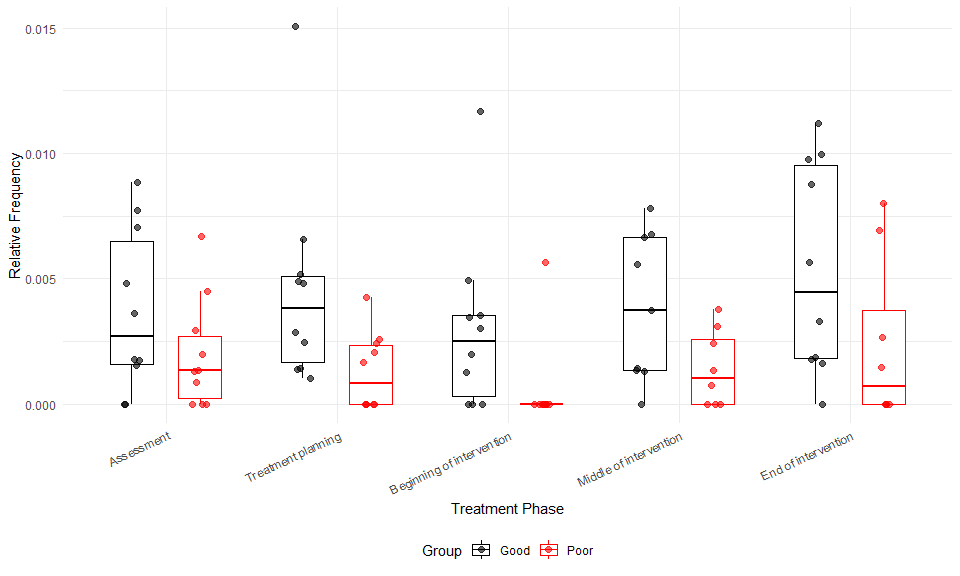

```r
results <- sequence_descriptives(
  data = data,
  treatment_phase_var = "Treatment_Phase",
  phase_order = c("Assessment", "Treatment planning", "Beginning of intervention",
                  "Middle of intervention", "End of intervention"),
  behavior_var = "Behavior",
  sequence = c("Empathy T", "Total agreement C"),
  combine_plots = T,  # FALSE for separate plots per group
  group_var = "Group",
  selected_groups = c("Good", "Poor"),
  use_relative_frequency = T
)
```

```r
library(DT)

stats_df <- results$statistics


numeric_cols <- names(stats_df)[sapply(stats_df, is.numeric)]

datatable(stats_df,
          options = list(
            pageLength = 5,
            scrollX = TRUE,
            dom = 'Bfrtip'
          )) %>%
  formatRound(columns = setdiff(numeric_cols, "Sample_Size"), digits = 3) %>%
  formatRound(columns = "Sample_Size", digits = 0)
```

|  | Sequence | Group | Treatment_Phase | Sample_Size | Mean | Median | SD | Percentile_5 | Percentile_95 | Skewness | Skewness_SE | Kurtosis | Shapiro_p_value | Normality |
| --- | --- | --- | --- | --- | --- | --- | --- | --- | --- | --- | --- | --- | --- | --- |
| 1 | Empathy T -&gt; Total agreement C | Poor | Assessment | 10 | 0.001965111291431792 | 0.00133176203725035 | 0.002191742159319497 | 0 | 0.005702917771883287 | 0.9313268983734222 | 0.7745966692414834 | -0.4587498797440817 | 0.06870047805766037 | Normal |
| 2 | Empathy T -&gt; Total agreement C | Poor | Treatment planning | 10 | 0.001304481087974146 | 0.0008361204013377926 | 0.00152726187103685 | 0 | 0.003516571011511792 | 0.5404433415218907 | 0.7745966692414834 | -1.208774620560805 | 0.02499003443687209 | Not Normal |
| 3 | Empathy T -&gt; Total agreement C | Poor | Beginning of intervention | 10 | 0.0005660377358490565 | 0 | 0.001789968486887762 | 0 | 0.003113207547169805 | 2.276839915321233 | 0.7745966692414834 | 3.57 | 1.003692813889069e-07 | Not Normal |
| 4 | Empathy T -&gt; Total agreement C | Poor | Middle of intervention | 8 | 0.001422923764550072 | 0.001048426656373389 | 0.001505044883097133 | 0 | 0.003536857890127784 | 0.3548577946292309 | 0.8660254037844386 | -1.739625583313503 | 0.1592628197696983 | Normal |
| 5 | Empathy T -&gt; Total agreement C | Poor | End of intervention | 8 | 0.002382187058286354 | 0.000725689404934688 | 0.003297524749314356 | 0 | 0.007636505212306127 | 0.7609017941339447 | 0.8660254037844386 | -1.345130395563188 | 0.009674081757929429 | Not Normal |
| 6 | Empathy T -&gt; Total agreement C | Good | Assessment | 10 | 0.003711139236329813 | 0.002688382262582092 | 0.00324992929889618 | 0 | 0.008360399799158976 | 0.3292863047443835 | 0.7745966692414834 | -1.633168056985955 | 0.2355920886214405 | Normal |
| 7 | Empathy T -&gt; Total agreement C | Good | Treatment planning | 10 | 0.004569691087104776 | 0.003839078758760963 | 0.004150706430636162 | 0.001184825739693537 | 0.01125032859771638 | 1.464360010181841 | 0.7745966692414834 | 1.249113152396733 | 0.006927934002503871 | Not Normal |
| 8 | Empathy T -&gt; Total agreement C | Good | Beginning of intervention | 10 | 0.002995335430170191 | 0.002502331411230955 | 0.003510288577775604 | 0 | 0.008660339386483371 | 1.337465789619233 | 0.7745966692414834 | 0.9404173011670229 | 0.01401935931743301 | Not Normal |
| 9 | Empathy T -&gt; Total agreement C | Good | Middle of intervention | 9 | 0.003845268636649434 | 0.003738317757009346 | 0.00292889975618347 | 0.0005167958656330749 | 0.007405475880052151 | 0.05216581136805383 | 0.816496580927726 | -1.899548615835817 | 0.2145892762412848 | Normal |
| 10 | Empathy T -&gt; Total agreement C | Good | End of intervention | 10 | 0.005389385476562707 | 0.004469226119437685 | 0.004192024727674112 | 0.0007293354943273904 | 0.01063488390033171 | 0.1397838716976432 | 0.7745966692414834 | -1.88292321754374 | 0.1384253237572789 | Normal |

# 3. Data analyses: answering the proposed research questions

## 3.1 What behaviors/sequences are more frequent?

The `sequence_heatmap` function is designed to analyze and visualize individual or sequences of behaviors. It generates a heatmap that displays the absolute or relative frequency of specific behaviors or sequences of behaviors across different moments (e.g., treatment phases). The function is highly customizable, allowing users to define behaviors/sequences and treatment phases, as well as specify the type of data desired (absolute or relative frequency). The researcher will also be able to flexibly group behaviors that they want to be treated as the same using a `+`, without permanently changing the data frame. It also allows for group comparison.

### Key Features

1. **Behavior and Sequence Analysis**:
   - Handles grouped behaviors flexibly (e.g., `"BehaviorA + BehaviorB"`), treating them as one single behavior.
2. **Customizable Inputs**:
   - Users can specify the columns for behaviors, treatment phases, and sessions in the dataset.
   - Allows customization of treatment phase levels and the order of behaviors/sequences in the heatmap.
3. **Frequency Calculation**:
   - Computes **absolute frequencies** (counts) or **relative frequencies** (proportions) of behaviors or sequences.
   - Calculates mean frequencies per phase by normalizing the sum of frequencies by the total number of sessions in each phase.
4. **Heatmap Visualization**:
   - Generates a heatmap using `ggplot2`, with behaviors/sequences on the y-axis and treatment phases on the x-axis.
   - The fill color of the heatmap represents the absolute or relative frequency of behaviors/sequences.
5. **Custom Ordering**:
   - Allows users to order behaviors/sequences in the heatmap either:
     - **Personalized**: In the same order as provided in `custom_sequences`.
     - **By Frequency**: Based on the total frequency of behaviors/sequences (highest to lowest).
6. **Group Separation**:
   - Supports separation of data by groups (e.g., `"Good"`, `"Poor"`) if a `group_var` is provided.
   - Generates separate heatmaps for each group, ensuring that the analysis is tailored to each subset of the data.
7. **Requested Libraries Handling**:
   - Checks for and loads required packages (`dplyr`, `ggplot2`, `tidyr`, `purrr`, `stringr`) and installs them if they are not installed.

### Function Arguments

[output not shown]

### Output: example usage

The function returns a heatmap or various heatmaps depending if the group argument includes a group variable. The following callings show different possible outputs.

#### 2 groups compared - Relative frequency - Personalized order

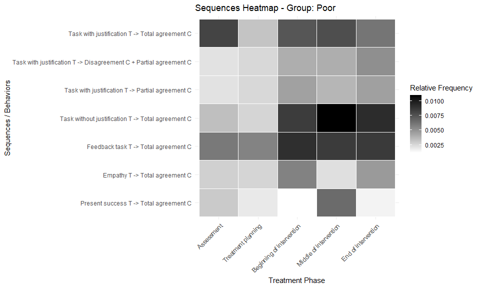

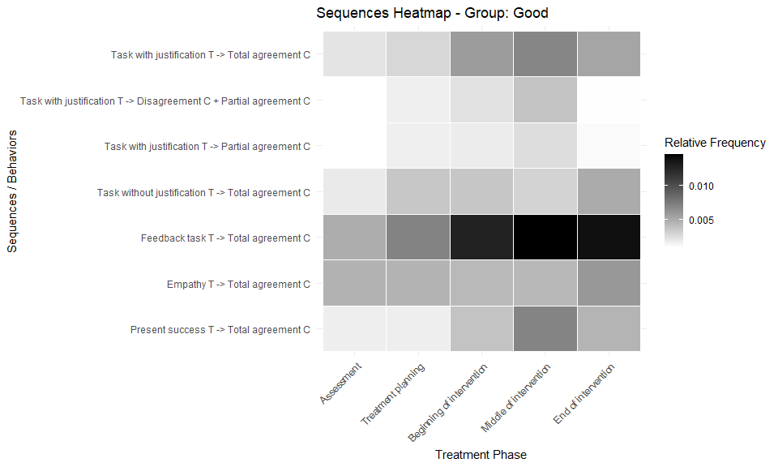

```r
sequence_heatmap(
  data = data,
  behavior_col = "Behavior",
  phase_col = "Treatment_Phase",
  session_col = "Observation",
  custom_sequences = list(
    c("Task with justification T", "Total agreement C"),
    c("Task with justification T", "Disagreement C + Partial agreement C"),
    c("Task with justification T", "Partial agreement C"),
    c("Task without justification T", "Total agreement C"),
    c("Feedback task T", "Total agreement C"),
    c("Empathy T", "Total agreement C"),
    c("Present success T", "Total agreement C")
  ),
  phase_levels = c("Assessment", "Treatment planning", "Beginning of intervention", "Middle of intervention", "End of intervention"),
  freq_type = "relative",
  custom_order = "personalized",
  group_var = "Group",
  selected_groups = c("Good", "Poor")
)
```

#### No group comparison - Absolute frequency - Order by total frequency

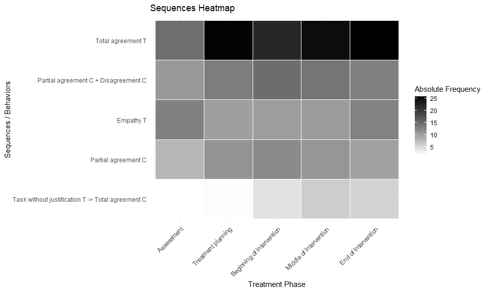

```r
sequence_heatmap(
  data = data,
  behavior_col = "Behavior",
  phase_col = "Treatment_Phase",
  session_col = "Observation",
  custom_sequences = list(
    c("Total agreement T"),
    c("Empathy T"),
    c("Partial agreement C"),
    c("Task without justification T", "Total agreement C"),
    c("Partial agreement C + Disagreement C")),
  phase_levels = c("Assessment", "Treatment planning", "Beginning of intervention", "Middle of intervention", "End of intervention"),
  freq_type = "absolute",
  custom_order = "frequency",
  group_var = NULL,
  selected_groups = c("Good", "Poor") # Only works if group_var is not NULL
)
```

## 3.2 How do behaviors/sequences evolve over time?

The `sequence_trajectory` function models how specific behavior sequences evolve across treatment phases using a standardized metric to allow comparison between different behaviors/sequences and different groups. It enables researchers to explore patterns of change (e.g., increasing, decreasing, stable) in the relative frequency of sequences, optional comparisons between groups. The function supports multiple polynomial shapes (linear, quadratic, cubic) to fit and visualize behavioral trends.

### Key Features

1. **Trajectory Modeling**:
   - Computes the relative frequency in a standardized metric of specific behaviors or behavior sequences across treatment phases.
   - Aggregates and averages frequencies to identify trends across sessions.
2. **Group-Based Analysis**:
   - If a grouping variable is provided, trajectories are computed separately for each group (e.g., `"Good"` vs `"Poor"`), enabling comparative analysis.
3. **Behavior Grouping with Flexibility**:
   - Supports combined behavior analysis using the `+` operator (e.g., `"BehaviorA + BehaviorB"`) for evaluating equivalent/similar behaviors.
4. **Clean Visualization**:
   - Plots behavioral trajectories using `ggplot2` with clear phase separation and optional faceting by group.
5. **Phase Control**:
   - Users can control the ordering of treatment phases.
6. **Flexible Confidence Intervals**:
   - Allows users to choose between *t*-based (default) and bootstrap confidence intervals in the plots.
   - This is especially useful when working with small samples or data that may depart from normality.

### Argument Descriptions

[output not shown]

### Output: example usage

The function returns a list with plots and model information:

- For **single-group** analysis:
  - A list of results for each sequence.
  - A combined vertical plot (`all_sequences_plot`) showing the relative frequency trajectories across phases.
- For **group comparisons**:
  - Results broken down by group and sequence.
  - A `comparison_plot` showing trajectory plots side-by-side across groups for all sequences.

Each plot includes: - Individual lines for each subject. - Group average trajectory with confidence intervals. - Best-fit polynomial model (in red) with AIC info.

#### Two single behaviors compared

The output shown answers the research question *How do behaviors/sequences evolve over time?*, so the `group_variable` argument is `NULL`.

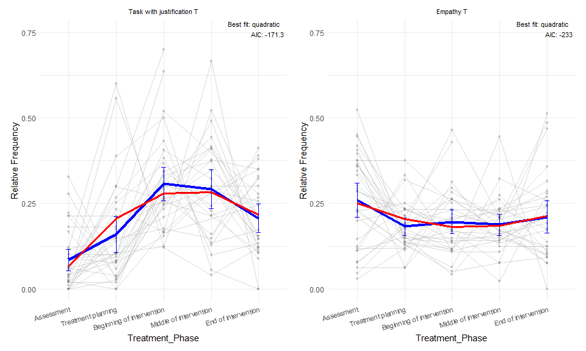

```r
# Two single behaviors compared

result <- sequence_trajectory(
  data = data,
  sequence = list(c("Task with justification T"), c("Empathy T")),
  behavior_var = "Behavior",
  phase_var = "Treatment_Phase",
  phase_order = c("Assessment", "Treatment planning", "Beginning of intervention", "Middle of intervention", "End of intervention"),
  observation_var = "Observation",
  id_var = "ID",
  group_variable = NULL,
  groups_compared = NULL,
  shapes = c("linear", "quadratic", "cubic")
)

result[["all_sequences_plot"]]
```

## 3.3 Do changes in behaviors/sequences differ across groups?

The `sequence_trajectory` allows for comparisons between groups using the argument `group_variable`, which needs to be filled with the name of the variable that contains the groups’ names. In the argument `groups_compared`, we need to indicate which groups from the `group_variable` we want to compare.

### Output

#### One sequence - Two groups compared

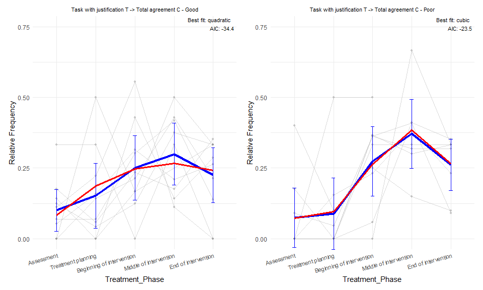

```r
result <- sequence_trajectory(
  data = data,
  sequence = list(c("Task with justification T", "Total agreement C")),
  behavior_var = "Behavior",
  phase_var = "Treatment_Phase",
  phase_order = c("Assessment", "Treatment planning", "Beginning of intervention", "Middle of intervention", "End of intervention"),
  observation_var = "Observation",
  id_var = "ID",
  group_variable = "Group",
  groups_compared = c("Good", "Poor"),
  shapes = c("linear", "quadratic", "cubic")
)

result[["comparison_plot"]]
```

#### Two sequences - Two groups compared

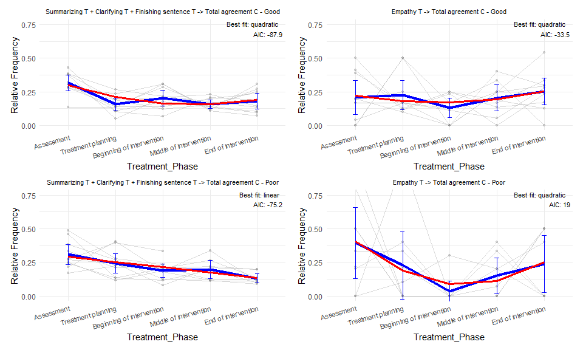

```r
result <- sequence_trajectory(
  data = data,
  sequence = list(c("Summarizing T + Clarifying T + Finishing sentence T", "Total agreement C"), c("Empathy T", "Total agreement C")),
  behavior_var = "Behavior",
  phase_var = "Treatment_Phase",
  phase_order = c("Assessment", "Treatment planning", "Beginning of intervention", "Middle of intervention", "End of intervention"),
  observation_var = "Observation",
  id_var = "ID",
  group_variable = "Group",
  groups_compared = c("Good", "Poor"),
  shapes = c("linear", "quadratic", "cubic")
)

result[["comparison_plot"]]
```